# StatInference Assignment

JRB

August 24, 2016

# PART 1: Simulation

# PART 2: Basic Inference : The Effect of Vitamin C on Tooth Growth in Guinea Pigs

## Introduction

We propose to analyze the length of odontoblasts for 60 guinea pigs that have received one of three dose levels of Vitamin C by of of two delivery methods (orange juice OJ) or ascorbic acid (VC). We will first perform some exploratory data analysis to generate some hypothesis that we will be statistically tested.

## Exploratory Data Analysis

### Graphical Aanlysis

We fill first plot the data set to represent the density of observations and some key statistics for each combination of delivery method at each dose level. The graph will compare side by side the tooth length for dose level for both OJ and VC.

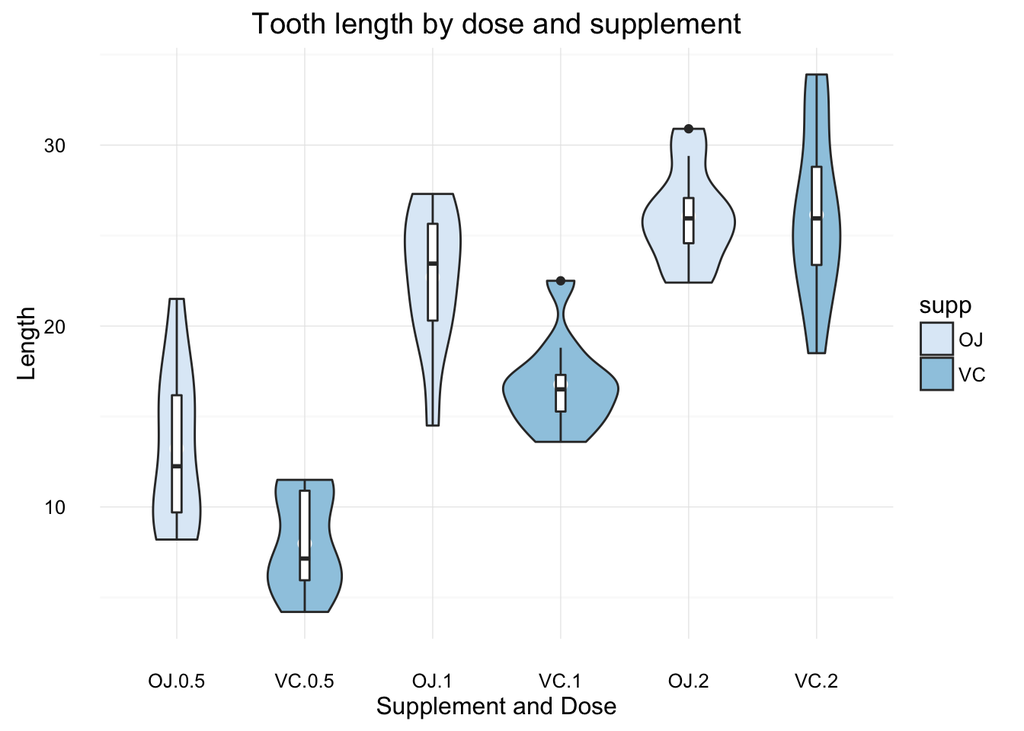

The figure illustrates that increasing doses of vitamin C would correspong to longer teeth and that the mean of admistration could impact tooth growth also. In the following section we will review some summary statitics that will help define hypothesis that would be statistically evaluated.

## Summary statistics and hypothesis generation

From Table 1, we can make the observation that tooth length mean varies by supplement type, the mean is greater for OJ. We will test the hypothesis that the mean observed length of OJ is greater than the mean observed length for VC. So, our hypothesis testing should determine if there’s a statistically significant effect of supplement on tooth length.  
***

Summary statistics for tooth length by supplement

| supp | n | Mean | Std.Dev | Sample Error |
| --- | --- | --- | --- | --- |
| OJ | 30 | 20.66333 | 6.61 | 1.21 |
| VC | 30 | 16.96333 | 8.27 | 1.51 |

Table 2 shows that an increase in dose results in an increase in mean tooth lentgh (larger means as dose increases)

Summary statistics for tooth length by dose

| dose | n | Mean | Std.Dev | Sample Error |
| --- | --- | --- | --- | --- |
| 0.5 | 20 | 10.605 | 4.50 | 1.01 |
| 1.0 | 20 | 19.735 | 4.42 | 0.99 |
| 2.0 | 20 | 26.100 | 3.77 | 0.84 |

From Table 3 we can formulate the assumption that the mean tooth length is larger at dose levels 0.5 and 1 mg for Orange Juice (OJ) compared to ascorbic acid (VC) but about the same for OJ and VC at dose leve of 2mg

Summary Statistics for tooth length by dose and supplement

| dose | supp | n | Mean | Std.Dev | Sample Error |
| --- | --- | --- | --- | --- | --- |
| 0.5 | OJ | 10 | 13.23 | 4.46 | 1.41 |
| 0.5 | VC | 10 | 7.98 | 2.75 | 0.87 |
| 1.0 | OJ | 10 | 22.70 | 3.91 | 1.24 |
| 1.0 | VC | 10 | 16.77 | 2.52 | 0.80 |
| 2.0 | OJ | 10 | 26.06 | 2.66 | 0.84 |
| 2.0 | VC | 10 | 26.14 | 4.80 | 1.52 |

## Inference

We have generated three hypothesis that we would like to test againts the null hypothesis.

## Hypothesis “Tooth length increases as dose increases”

To test this hypothesis, we will compare tooth length means at different dose levels (regardless of mean of administration).

Test 1: 0.5 mg vs 1 mg

the t value to exceed is 1.68597

Welch Two Sample t-test: `len` by `dose`

| Test statistic | df | P value | Alternative hypothesis |
| --- | --- | --- | --- |
| -6.5 | 38 | 0 * * * | two.sided |